# Exercise 2 (20 minutes)

You practice: visualizing the adjustment — a before/after coefficient plot and model predictions, on the carbon divide. When you're done, assist some of the others …

*(Keep working in the R script from Exercise 1 — you already have `Dat`, `ols_biv`, and `ols_adj`. If not, the starter code and the "Stuck?" box are in Exercise 1.)*

1. **Write it yourself: a before/after coefficient plot.** Tidy *both* models, keep only the region terms, stack them, and plot the two sets of region coefficients side by side with `position_dodge()` — so you can see each gap shrink when GDP enters.

As on the Lecture 8 slide *The adjusted effect, drawn*: `tidy()` each model, drop the intercept (and `gdp_k`) with `filter()`, then `bind_rows(bivariate, adjusted, .id = "model")`. Map `color = model` and add `position = position_dodge(width = 0.5)` to `geom_pointrange()`.

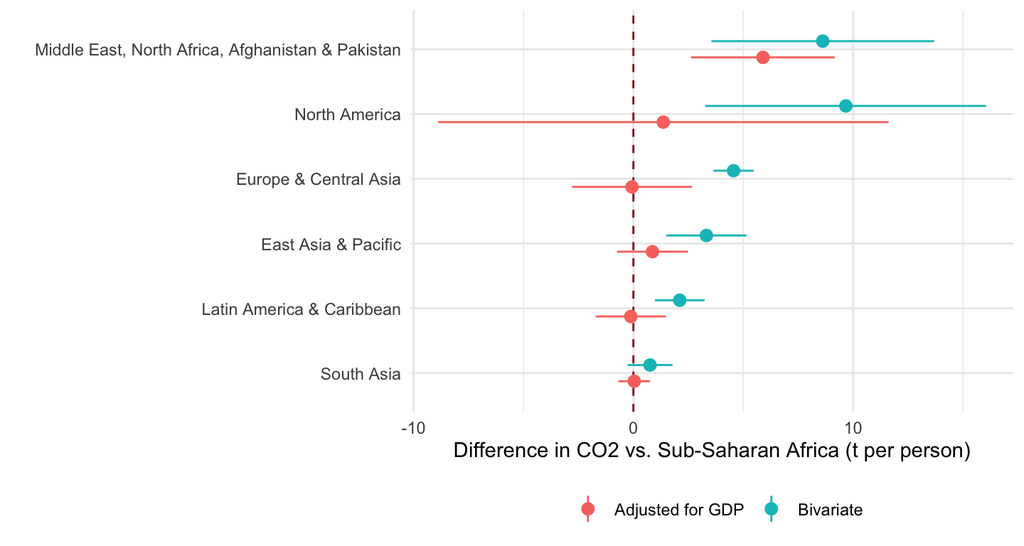

```r
bivariate <- ols_biv %>%
  tidy() %>%                                 # Coefficients as a tibble
  filter(term != "(Intercept)") %>%          # Keep only the region terms
  mutate(term = str_remove(term, "region"))  # "regionEurope ..." -> "Europe ..."

adjusted <- ols_adj %>%
  tidy() %>%
  filter(term != "(Intercept)" & term != "gdp_k") %>%
  mutate(term = str_remove(term, "region"))

plotdata <- bind_rows(bivariate, adjusted, .id = "model") %>%
  mutate(model = case_when(model == "1" ~ "Bivariate",           # Model 1
                           model == "2" ~ "Adjusted for GDP"))  # Model 2

ggplot(plotdata, aes(x = reorder(term, estimate), y = estimate, color = model)) +
  geom_hline(yintercept = 0, color = "#901A1E", lty = "dashed") +
  geom_pointrange(aes(ymin = conf.low, ymax = conf.high),
                  position = position_dodge(width = 0.5)) +
  coord_flip() +
  labs(x = "", y = "Difference in CO2 vs. Sub-Saharan Africa (t per person)",
       color = "") +
  theme_minimal() +
  theme(legend.position = "bottom")
```

2. Which statement matches your plot?
3. **Write it yourself: a prediction plot.** From `ols_adj`, predict CO2 across a GDP range (say 1–130) **holding region at the reference, Sub-Saharan Africa**, and plot the fitted line with its confidence ribbon.

Build `tibble(gdp_k = 1:130, region = "Sub-Saharan Africa")`, then `predict(ols_adj, newdata = ..., interval = "confidence")$fit`, `as_tibble()` it and `bind_cols()` back. Plot with `geom_ribbon()` + `geom_line()`.

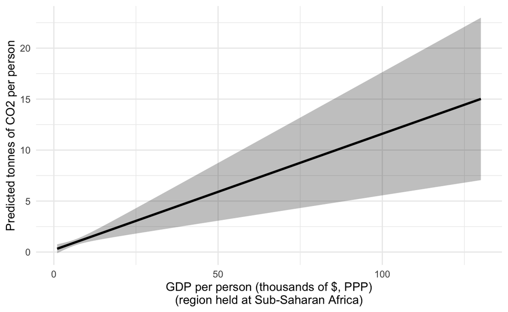

```r
fict <- tibble(gdp_k = 1:130, region = "Sub-Saharan Africa")

fict <- predict(ols_adj, newdata = fict,
                interval = "confidence", level = 0.95)$fit %>%
  as_tibble() %>% bind_cols(fict, .)

ggplot(fict, aes(x = gdp_k, y = fit)) +
  geom_ribbon(aes(ymin = lwr, ymax = upr), alpha = 0.3) +
  geom_line(linewidth = 1) +
  labs(x = "GDP per person (thousands of $, PPP)\n(region held at Sub-Saharan Africa)",
       y = "Predicted tonnes of CO2 per person") +
  theme_minimal()
```

4. **Write one sentence** (as a `# comment`) describing what the prediction line shows, then compare:

*Within a given region, predicted emissions rise steadily with national wealth — about 0.11 extra tonnes per person for every additional $1,000 of GDP per person — which is why controlling for wealth absorbs so much of the raw regional gaps.*

5. **Discuss with your neighbour** — three steps:
   1. Your two figures make the same point differently. Which better tells a non-statistician that "the regional gaps are mostly wealth" — the before/after coefficient plot or the prediction line?
   2. Can we say wealth *causes* emissions here? Name one thing, besides GDP, that differs between rich and poor countries and could drive emissions.
   3. Middle East & North Africa stays high even at equal GDP. What does a *large surviving* coefficient, after controlling, tell you — and what does a *vanishing* one tell you?

**(a)** The prediction line reads like a graph and needs no reference-category vocabulary; the coefficient plot is compact but assumes the reader knows what "vs. Sub-Saharan Africa" means. **(b)** No — these are descriptive cross-country comparisons; energy mix, industry structure, climate, and fossil-fuel endowments all differ and could drive emissions (all potential confounders). **(c)** A *vanishing* coefficient means the raw gap was "just" the control (wealth); a *surviving* one (MENA) means there is something regional beyond wealth — here, oil and gas.

**Bonus (for the fast):** swap the continuous control `gdp_k` for the categorical `income_level`. Do the region gaps shrink in the same way?

```r
Dat <- Dat %>% mutate(income_level = fct_relevel(income_level, "Low income"))

modelsummary(
  list("CO2 (+ GDP)" = ols_adj,
       "CO2 (+ income group)" = lm_robust(co2 ~ region + income_level, data = Dat)),
  stars = TRUE, gof_map = c("nobs", "r.squared"))
```

|  | CO2 (+ GDP) | CO2 (+ income group) |
| --- | --- | --- |
| (Intercept) | 0.208 | -0.263 |
|  | (0.248) | (0.318) |
| regionEast Asia & Pacific | 0.866 | -0.211 |
|  | (0.820) | (0.858) |
| regionEurope & Central Asia | -0.064 | -1.243 |
|  | (1.379) | (1.108) |
| regionLatin America & Caribbean | -0.118 | -2.429** |
|  | (0.808) | (0.915) |
| regionMiddle East, North Africa, Afghanistan & Pakistan | 5.895*** | 5.246** |
|  | (1.657) | (1.791) |
| regionNorth America | 1.360 | 2.388 |
|  | (5.194) | (3.471) |
| regionSouth Asia | 0.039 | -0.184 |
|  | (0.368) | (0.740) |
| gdp_k | 0.114*** |  |
|  | (0.033) |  |
| income_levelHigh income |  | 8.463*** |
|  |  | (1.448) |
| income_levelLower middle income |  | 0.975+ |
|  |  | (0.510) |
| income_levelUpper middle income |  | 4.424*** |
|  |  | (0.864) |
| Num.Obs. | 190 | 190 |
| R2 | 0.455 | 0.438 |

+ p < 0.1, * p < 0.05, ** p < 0.01, *** p < 0.001

Both controls tell the same story — wealth, measured either way, absorbs most of the regional differences. Good findings should not hinge on one particular way of measuring the control.